## COURSE: VISUAL ANALYTICS FOR POLICY & MANAGEMENT - EVANS SCHOOL UW

### DELIVERABLE 3 Spatial Analysis using Nigeria LSMS-ISA 2015-16

### by: Sebastián Wood

### I. Working with the LSMS-ISA Nigeria Wave 3 Data

1. This dataset was previously cleaned and analyzed using Stata by creating summary statistics at th state level. Therefore, the unit of analysis becomes each state of Nigeria in 2015-16.

#### 1. Open the EPAR LSMS-ISA Nigeria Wave 3 data

```r
rm(list = ls())

linkCSV='https://raw.githubusercontent.com/sebawood1/deliverable-3/main/EPAR_NGA_states.csv'

dataNGA=read.csv(linkCSV)
#View(dataNGA)
```

#### 2. Select some of the variables and create a new Dataset

```r
library(tidyverse)
dataNGA <- select(dataNGA, state, daily_percap_cons, months_food_insec, lvstck_holding_tlu, months_food_insecure)
```

This is what we have:

```r
str(dataNGA)
```

```
## 'data.frame':    38 obs. of  5 variables:
##  $ state               : chr  "abia" "adamawa" "akwa ibom" "anambra" ...
##  $ daily_percap_cons   : num  628 208 830 556 268 ...
##  $ months_food_insec   : num  0.452 0.517 0.458 2.039 0.22 ...
##  $ lvstck_holding_tlu  : num  0.17 3.146 0.196 0.345 2.105 ...
##  $ months_food_insecure: num  0.327 0.375 0.213 0.605 0.129 ...
```

Let’s explore the behavior of each numerical variable:

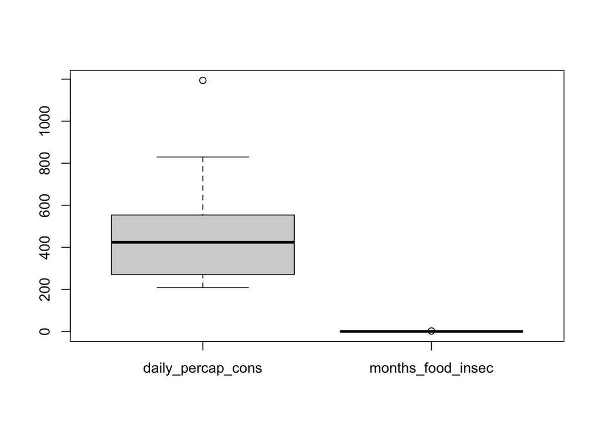

```r
boxplot(dataNGA[,c('daily_percap_cons','months_food_insec')])
```

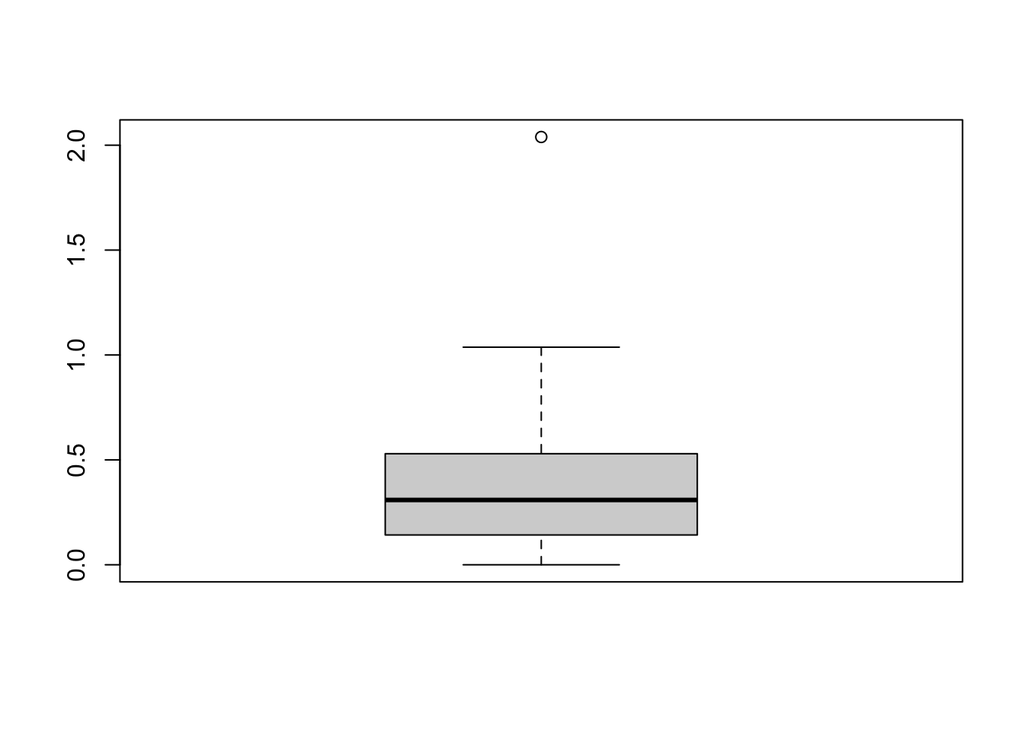

```r
boxplot(dataNGA['months_food_insec'])
```

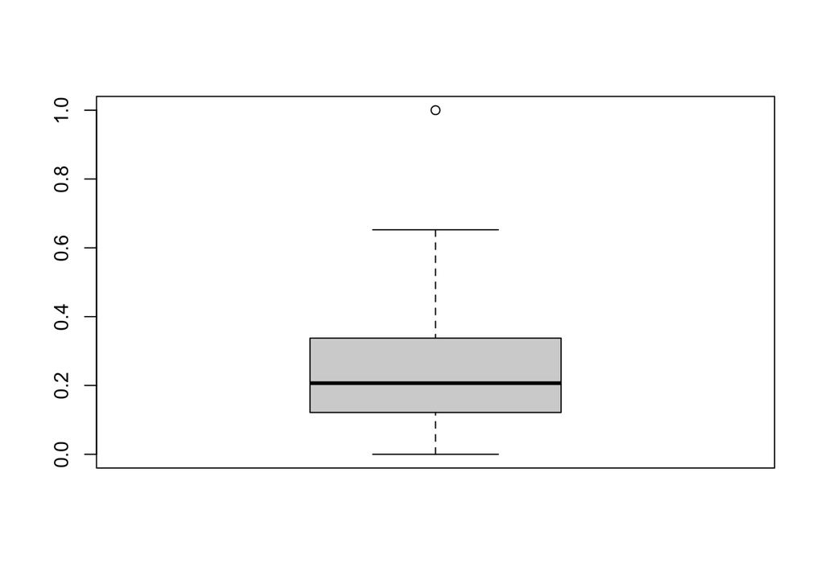

```r
boxplot(dataNGA['months_food_insecure'])
```

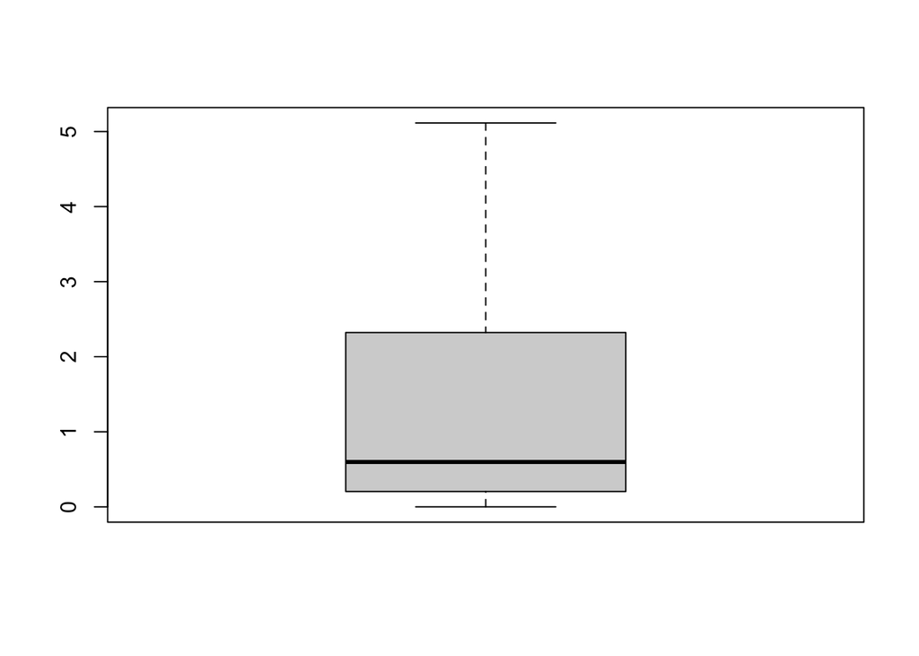

```r
boxplot(dataNGA['lvstck_holding_tlu'])
```

```r
dataNGA %>% mutate(months_food_insecure=1-months_food_insecure)
```

```
##          state daily_percap_cons months_food_insec lvstck_holding_tlu
## 1         abia          627.5453       0.451923070       0.1704347900
## 2      adamawa          208.2433       0.516949180       3.1459482000
## 3    akwa ibom          829.6387       0.458333340       0.1961017000
## 4      anambra          556.1836       2.039024400       0.3446625800
## 5       bauchi          268.4504       0.220238090       2.1052084000
## 6      bayelsa          553.6738       0.308823530       0.0004761905
## 7        benue          358.1065       0.006493507       0.5528276000
## 8        borno          304.3308       0.280898870       0.6298630200
## 9  cross river          380.5765       0.645669280       0.0750442450
## 10       delta          661.6783       0.145038170       0.2211711700
## 11      ebonyi          325.7514       0.719424490       0.3855038900
## 12         edo          602.2120       0.288659780       0.1498000000
## 13       ekiti          460.7704       0.159420300       0.3269444400
## 14       enugu          480.4179       0.120300750       0.3893103600
```

[output cut: 63 more lines]

In the last plot I detected different data ranges. Let’s try **standardization**:

```r
dataNGA$daily_percap_cons_S=as.vector(scale(dataNGA$daily_percap_cons))
dataNGA$months_food_insec_S=as.vector(scale(dataNGA$months_food_insec))
dataNGA$months_food_insecure_S=as.vector(scale(dataNGA$months_food_insecure))
dataNGA$lvstck_holding_tlu_S=as.vector(scale(dataNGA$lvstck_holding_tlu))
```

```r
library("tidyr")
# dataNGA <- dataNGA %>% drop_na() This erases rows that contain NA in any variable
vars <- c("daily_percap_cons","months_food_insecure", "lvstck_holding_tlu")
dataNGA <- dataNGA %>% drop_na(any_of(vars)) # We delete states with no observations (no data)
```

#### 5. Let’s summarize the three indexes using clustering. Let’s try **pam** again:

```r
set.seed(123) # for replication purposes

#variables needed
scaledIndexes=c('daily_percap_cons_S','months_food_insecure_S', 'lvstck_holding_tlu')

#computing distances among countries
distMatrix=cluster::daisy(dataNGA[,scaledIndexes])

#computing the clusters
res.pam=cluster::pam(x=distMatrix,
                     k = 3,
                     cluster.only = F,
                     )
```

Let’s save the cluster info into the data frame:

```r
#adding column as a factor variable
dataNGA$cluster=as.factor(res.pam$clustering)
```

#### 6. Let’s see how can we interpret the cluster labels:

```r
theVars=c('daily_percap_cons_S','months_food_insecure_S','lvstck_holding_tlu','cluster')
aggregate(.~cluster,
          data=dataNGA[,theVars],
          FUN=median)
```

```
##   cluster daily_percap_cons_S months_food_insecure_S lvstck_holding_tlu
## 1       1           0.5289368            -0.02550124          0.2041667
## 2       2          -0.7190291             0.03325327          3.3093248
## 3       3          -0.8596956            -0.66590703          1.4919971
```

Recoding the cluster values for a correct interpretation:

```r
dataNGA$cluster=factor(dataNGA$cluster,
                           levels=c(3,1,2),
                           labels=c("Low","Mid","High"),
                           ordered=T)
```

### II. Spatial Analysis using Nigeria Data:

#### 1. The purpose is to represent that information into a map. Let’s bring the map:

First I had to download a Nigeria Shapefile for zones and regions from google and then convert the SHP file to GeoJSon using the [following website](https://mygeodata.cloud/converter/shp-to-geojson)

```r
linkMap="https://github.com/sebawood1/deliverable-3/raw/main/mygeodata/sdr_subnational_boundaries2.geojson"

library(sf)
```

```r
mapNigeria=read_sf(linkMap)
```

This is the data that came with the map:

```r
# see data in map
head(mapNigeria)
```

```
## Simple feature collection with 6 features and 27 fields
## Geometry type: MULTIPOLYGON
## Dimension:     XY
## Bounding box:  xmin: 4.140833 ymin: 10.02218 xmax: 14.67858 ymax: 13.89139
## Geodetic CRS:  WGS 84
## # A tibble: 6 × 28
##   ISO   FIPS  DHSCC SVYTYPE SVYYEAR CNTRYNAMEE CNTRYNA…¹ CNTRY…² DHSRE…³ DHSRE…⁴
##   <chr> <chr> <chr> <chr>     <dbl> <chr>      <chr>     <chr>   <chr>   <chr>
## 1 NG    NI    NG    DHS        2018 Nigeria    Nigéria   Nigeria Sokoto  <NA>
## 2 NG    NI    NG    DHS        2018 Nigeria    Nigéria   Nigeria Zamfara <NA>
## 3 NG    NI    NG    DHS        2018 Nigeria    Nigéria   Nigeria Katsina <NA>
## 4 NG    NI    NG    DHS        2018 Nigeria    Nigéria   Nigeria Jigawa  <NA>
## 5 NG    NI    NG    DHS        2018 Nigeria    Nigéria   Nigeria Yobe    <NA>
## 6 NG    NI    NG    DHS        2018 Nigeria    Nigéria   Nigeria Borno   <NA>
## # … with 18 more variables: DHSREGSP <chr>, SVYID <dbl>, REG_ID <chr>,
## #   Svy_Map <chr>, MULTLEVEL <chr>, LEVELRNK <dbl>, REGVAR <chr>,
## #   REGCODE <dbl>, REGNAME <chr>, OTHREGVAR <chr>, OTHREGCO <dbl>,
## #   OTHREGNA <chr>, LEVELCO <chr>, LEVELNA <chr>, REPALLIND <chr>,
## #   REGNOTES <chr>, SVYNOTES <chr>, geometry <MULTIPOLYGON [°]>, and
## #   abbreviated variable names ¹CNTRYNAMEF, ²CNTRYNAMES, ³DHSREGEN, ⁴DHSREGFR
```

#### 2. First, I need to modify the key merging variable so the merge ocurrs succesfully.

```r
#dataNGA$farm_area_S=as.vector(scale(dataNGA$farm_area))
dataNGA$REGNAME=dataNGA$state
#mapNigeria %>% mutate_if(is.character, str_to_lower) -> mapNigeria
mapNigeria[[19]] <- tolower(mapNigeria[[19]])


#df %>% mutate_if(is.character, str_to_upper) -> df THIS WORKS FOR ALL STRING
#df[[1]] <- toupper(df[[1]]) THIS WORKS FOR ONLY A PARTICULAR VAR
```

```r
mapNigeria_indexes=merge(mapNigeria, #map first
                   dataNGA,
                   by='REGNAME')
```

The object **mapNigeria_indexes** is a map that includes the information from **Nigeria**:

```r
str(mapNigeria_indexes)
```

```
## Classes 'sf' and 'data.frame':   37 obs. of  38 variables:
##  $ REGNAME               : chr  "abia" "adamawa" "akwa ibom" "anambra" ...
##  $ ISO                   : chr  "NG" "NG" "NG" "NG" ...
##  $ FIPS                  : chr  "NI" "NI" "NI" "NI" ...
##  $ DHSCC                 : chr  "NG" "NG" "NG" "NG" ...
##  $ SVYTYPE               : chr  "DHS" "DHS" "DHS" "DHS" ...
##  $ SVYYEAR               : num  2018 2018 2018 2018 2018 ...
##  $ CNTRYNAMEE            : chr  "Nigeria" "Nigeria" "Nigeria" "Nigeria" ...
##  $ CNTRYNAMEF            : chr  "Nigéria" "Nigéria" "Nigéria" "Nigéria" ...
##  $ CNTRYNAMES            : chr  "Nigeria" "Nigeria" "Nigeria" "Nigeria" ...
##  $ DHSREGEN              : chr  "Abia" "Adamawa" "Akwa Ibom" "Anambra" ...
##  $ DHSREGFR              : chr  NA NA NA NA ...
##  $ DHSREGSP              : chr  NA NA NA NA ...
##  $ SVYID                 : num  528 528 528 528 528 528 528 528 528 528 ...
##  $ REG_ID                : chr  "NGDHS2018433041" "NGDHS2018433021" "NGDHS2018433061" "NGDHS2018433042" ...
```

[output cut: 30 more lines]

Notice that the new map has the same amount of rows of the dataNGA data frame. The original map is still useful, as we will see next.

#### 4. Let me plot the original map, this will be our **base map**:

1. Base layer:

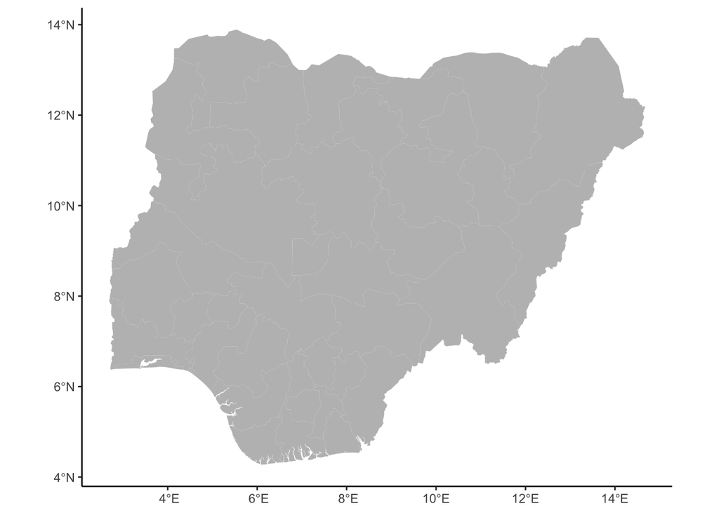

```r
library(ggplot2)
# plot original map
baseMap= ggplot(data=mapNigeria) + theme_classic() +
         geom_sf(fill='grey',
                 color=NA) # border color
#see
baseMap
```

#### 5. Data layer:

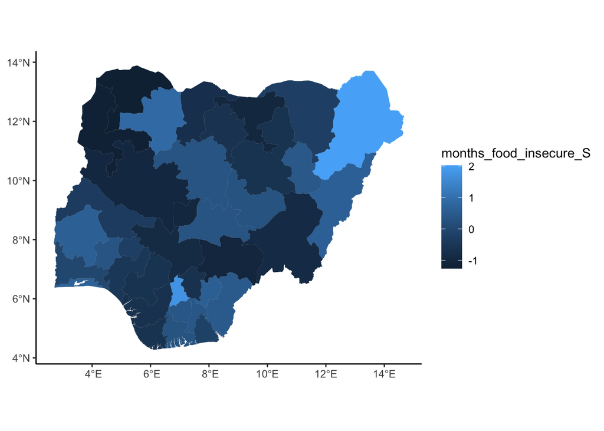

```r
numericMap= baseMap + geom_sf(data=mapNigeria_indexes,
                       aes(fill=months_food_insecure_S), # variable from mapWorld_indexes
                       color=NA)
numericMap
```

#### 5.b: Household Daily per capita consumption (Standarized by state).

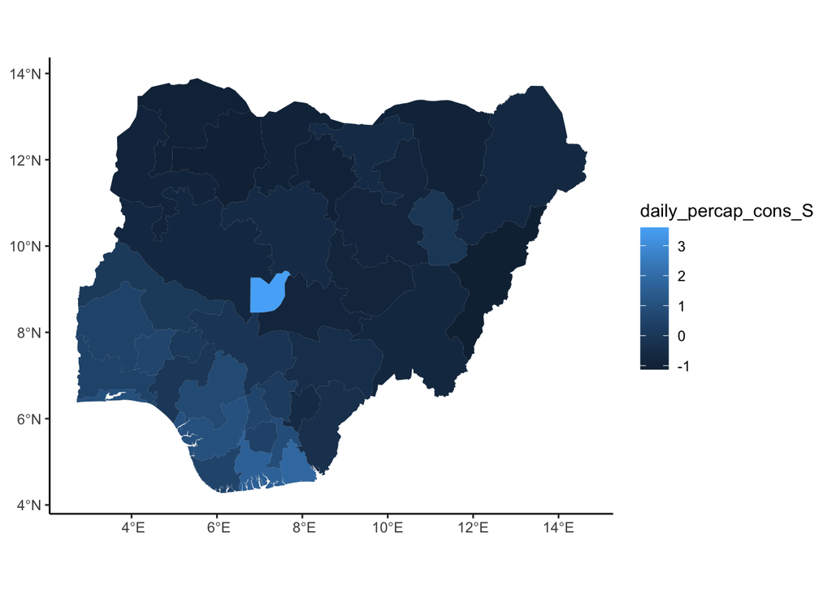

```r
numericMap= baseMap + geom_sf(data=mapNigeria_indexes,
                       aes(fill=daily_percap_cons_S), # variable from mapWorld_indexes
                       color=NA)
numericMap
```

#### 5.c: Household Livestock Stocks (Tropical Livestock Units) (Standarized by state).

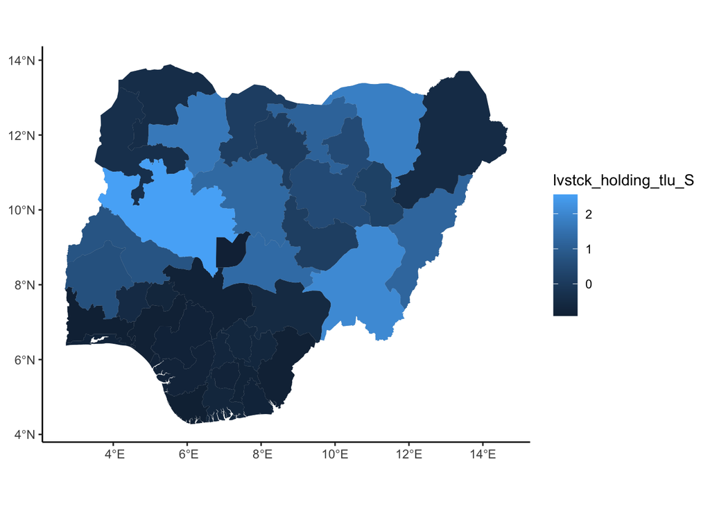

```r
numericMap= baseMap + geom_sf(data=mapNigeria_indexes,
                       aes(fill=lvstck_holding_tlu_S), # variable from mapWorld_indexes
                       color=NA)
numericMap
```

We can customize the color sequence with **scale_fill_gradient**:

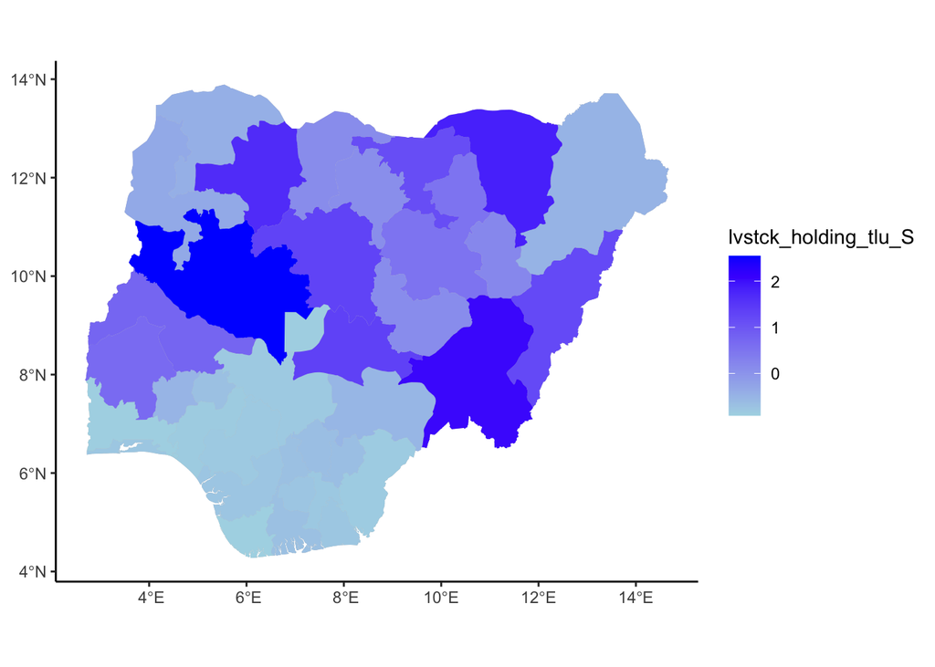

```r
numericMap + scale_fill_gradient(low = 'lightblue',
                                 high= 'blue')
```

#### 6. Let’s try the a map using the cluster information (**categorical values**):

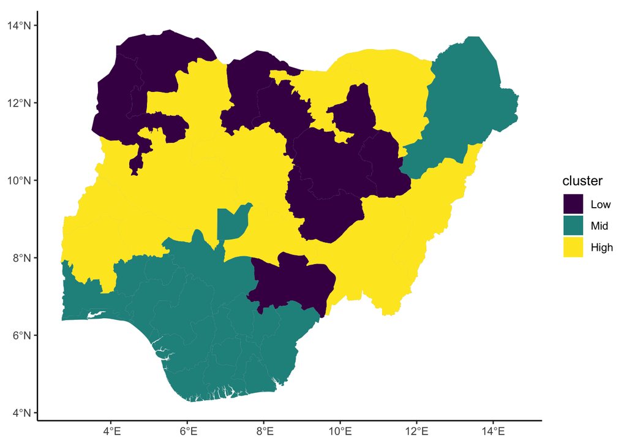

```r
categoricalMap= baseMap + geom_sf(data=mapNigeria_indexes,
                           aes(fill=cluster), # variable from mapWorld_indexes
                           color=NA)
categoricalMap
```

Notice that ggplot chose a good color palette. You can choose another the palette (get it from [here](http://colorbrewer2.org/)), for example:

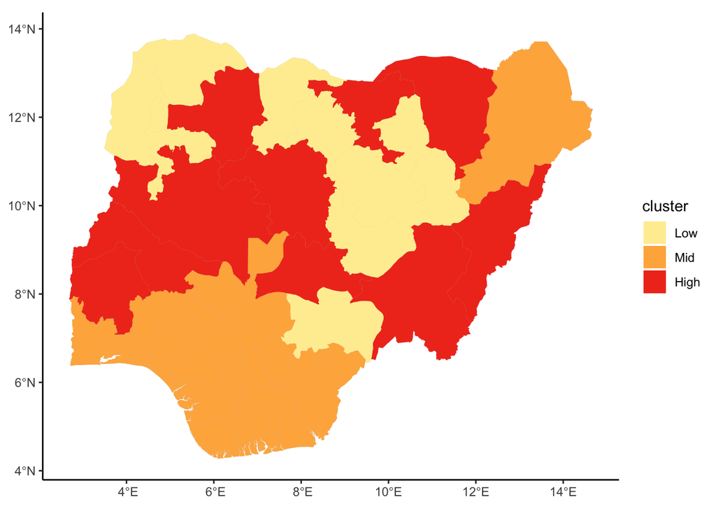

```r
# custom palette
categoricalMap + scale_fill_brewer(palette ='YlOrRd')
```

Some more customization:

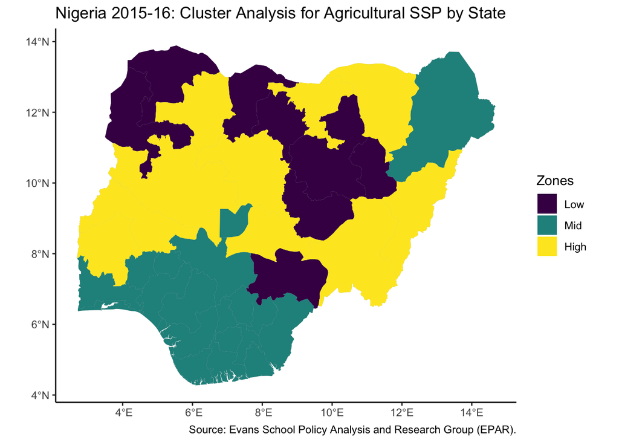

```r
#Add titles:
titleText='Nigeria 2015-16: Cluster Analysis for Agricultural SSP by State'
sourceText='Source: Evans School Policy Analysis and Research Group (EPAR).'
x_axis='Number of Months Food Insecure'
y_axis='Percentage of Total Households surveyed (%)'
check="Zones"
categoricalMap = categoricalMap + labs(title=titleText,
                    # x =x_axis,
                     #y =y_axis,
                     caption = sourceText,
                     fill =check)
categoricalMap
```

```r
#previously
#Legend_labels=c('1_worst',2,'3_best')
#Legend_title="Nigeria_Order\n(grey is missing)" #\n is new line

#now
#categoricalMap + scale_fill_brewer(palette ='YlOrRd',
                                #   direction = -1, # important!
                                #   labels=Legend_labels,
                                #   name=Legend_title)
```